# Untitled

## multiple testing correction

$P(X <= -2 | \mu=0,\sigma=2)$

We should think of hypothesis testing as a non-errorfree method of making decisions. There will be times when we declare something significant and accept

$H_1$ but we will be wrong. These decisions are also called “false positives” or “false discoveries”, this is also known as “type I error”. Similary, we can fail to reject a hypothesis when we actually should. These cases are known as “false negatives”, also known as “type II error”.

The ratio of true negatives to the sum of true negatives and false positives ($\frac{TN}{FP+TN}$) is known as specificity. And we usually want to decrease the FP and get higher specificity. The ratio of true positives to the sum of true positives and false negatives ($\frac{TP}{TP+FN}$) is known as sensitivity. And, again we usually want to decrease the FN and get higher sensitiviy. Sensitivity is also known as “power of a test” in the context of hypothesis testing. More powerful tests will be higly sensitive and will do less type II errors. For the t-test the power is positively associated with sample size and the effect size. Higher the sample size, smaller the standard error and looking for the larger effect sizes will similary increase the power.

The general summary of these the different combination of the decisions are included in the table below.

|  | $H_0$ is TRUE, [Gene is NOT differentially expressed] | $H_1$ is TRUE, [Gene is differentially expressed] |  |
| --- | --- | --- | --- |
| Accept $H_0$ (claim that the gene is not differentially expressed) | True Negatives (TN) | False Negatives (FN) ,type II error | $m_0$: number of truly null hypotheses |
| reject $H_0$ (claim that the gene is differentially expressed) | False Positives (FP) ,type I error | True Positives (TP) | $m-m_0$: number of truly alternative hypotheses |

We expect to make more type I errors as the number of tests increase, that means we will reject the null hypothesis by mistake. For example, if we performe a test the 5% significance level, there is a 5% chance of incorrectly rejecting the null hypothesis if the null hypothesis is true. However, if we make 1000 tests where all null hypotheses are true for each of them, the average number of incorrect rejections is 50. And if we apply the rules of probability, there are is almost a 100% chance that we will have at least one incorrect rejection. There are multiple statistical techniques to prevent this from happening. These techniques generally shrink the P-values obtained from multiple tests to higher values, if the individual P-value is low enough it survives this process. The most simple method is just to multiply the individual, P-value ($p_i$) with the number of tests ($m$): $m \cdot p_i$, this is called “bonferonnni correction”. However, this is too harsh if you have thousands of tests. Other methods are developed to remedy this. Those methods rely on ranking the P-values and dividing $m \cdot p_i$ by the rank,$i$, :$\frac{m \cdot p_i }{i}$, this is derived from Benjamini–Hochberg procedure. This procedure is developed to control for “False Discovery Rate (FDR)” , which is proportion of false positives among all significant tests. And in practical terms, we get the “FDR adjusted P-value” from the procedure described above. This gives us an estimate of proportion of false discoveries for a given test.

One final method that is also popular is called the “q-value” method and related . This procedure relies on estimating the proportion of true null hypotheses from the distribution of raw p-values and using that quantity to come up with what is called a “q-value”. That can be practically defined as “the proportion of significant features that turn out to be false leads.” A q-value 0.01 would mean 1% of the tests called significant at this level will be truly null on average. This is a similar quantity to the one estimated by “FDR adjusted P-value” method above. Within the genomics community q-value and FDR adjusted P-value are synoymous.

In R, the base function `p.adjust()` implements most of the p-value correction methods described above. For the q-value, we can use the `qvalue` package from Bioconductor. Below we are demonstrating how touse them on a set of simulated p-values.The plot shows that Bonferroni correction does a terrible job. FDR(BH) and q-value approach are better but q-value approach is more permissive than FDR(BH).

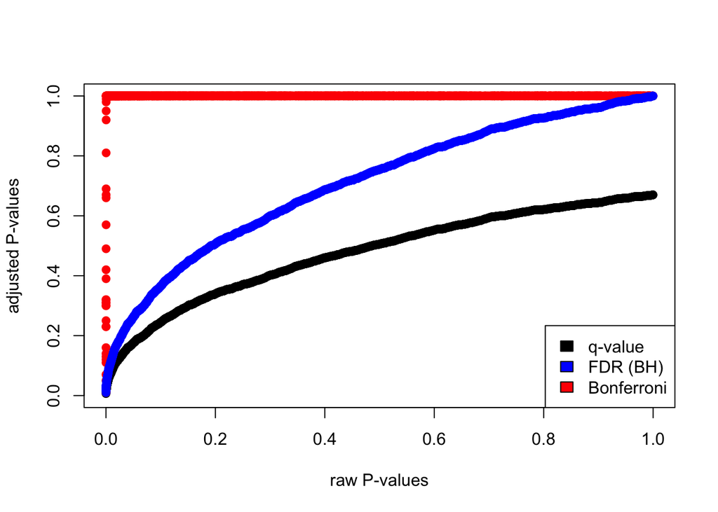

```r
library(qvalue)
data(hedenfalk)

qvalues <- qvalue(hedenfalk$p)$q
bonf.pval=p.adjust(hedenfalk$p,method ="bonferroni")
fdr.adj.pval=p.adjust(hedenfalk$p,method ="fdr")

plot(hedenfalk$p,qvalues,pch=19,ylim=c(0,1),
     xlab="raw P-values",ylab="adjusted P-values")
points(hedenfalk$p,bonf.pval,pch=19,col="red")
points(hedenfalk$p,fdr.adj.pval,pch=19,col="blue")
legend("bottomright",legend=c("q-value","FDR (BH)","Bonferroni"),
       fill=c("black","blue","red"))
```

generate exp matrix for exercises

```r
sd <- 0.2*sqrt(4/rchisq(1000,df=4))
data <- matrix(rnorm(1000*6,sd=sd),1000,6)
rownames(data) <- paste("Gene",1:1000)
data[1:100,4:6] <- data[1:100,4:6] + 2
```

process Xianjun data

```r
df=read.table("~/Downloads/TSS-based.cm1w.all.bestbin.lm.0.10.tab.txt",
           header=T,sep="\t")
df2=df[,c("H3k4me3","H3k27me3","measured_log2")]
df3=df2[df$predicted_C==0,]


 cor(df2$H3k4me3,df2$measured_log2)
```

```
## [1] 0.806933
```

```r
 cor(df2$H3k27me3,df2$measured_log2)
```

```
## [1] -0.2109209
```

```r
 cor(df3$H3k4me3,df3$measured_log2)
```

```
## [1] 0.2706311
```

```r
 cor(df3$H3k27me3,df3$measured_log2)
```

```
## [1] 0.1260365
```

```r
 mod.all=lm(df2$measured_log2 ~ df2$H3k27me3+ df2$H3k4me3 )
 mod.k4=lm(df2$measured_log2 ~  df2$H3k4me3 )
 anova(mod.k4,mod.all,test="F")
```

```
## Analysis of Variance Table
##
## Model 1: df2$measured_log2 ~ df2$H3k4me3
## Model 2: df2$measured_log2 ~ df2$H3k27me3 + df2$H3k4me3
##   Res.Df   RSS Df Sum of Sq      F    Pr(>F)
## 1  13729 90306
## 2  13728 84828  1    5477.2 886.38 < 2.2e-16 ***
## ---
## Signif. codes:  0 '***' 0.001 '**' 0.01 '*' 0.05 '.' 0.1 ' ' 1
```

```r
 summary(mod.all)
```

```
##
## Call:
## lm(formula = df2$measured_log2 ~ df2$H3k27me3 + df2$H3k4me3)
##
## Residuals:
##      Min       1Q   Median       3Q      Max
## -11.0564  -1.0702  -0.3066   1.2486  10.8950
##
## Coefficients:
##              Estimate Std. Error t value Pr(>|t|)
## (Intercept)  -9.11803    0.05980 -152.48   <2e-16 ***
## df2$H3k27me3 -0.54532    0.01832  -29.77   <2e-16 ***
## df2$H3k4me3   2.29815    0.01417  162.17   <2e-16 ***
## ---
## Signif. codes:  0 '***' 0.001 '**' 0.01 '*' 0.05 '.' 0.1 ' ' 1
##
## Residual standard error: 2.486 on 13728 degrees of freedom
## Multiple R-squared:  0.6723, Adjusted R-squared:  0.6723
## F-statistic: 1.408e+04 on 2 and 13728 DF,  p-value: < 2.2e-16
```

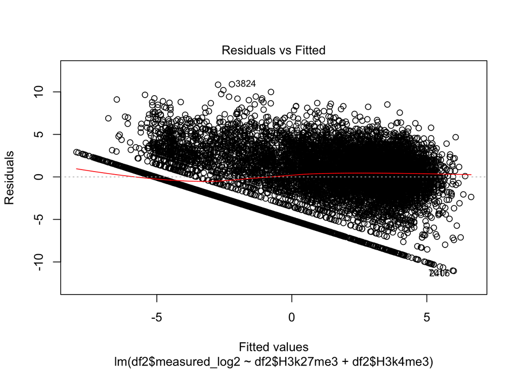

```r
 plot(mod.all,which=1)
```